# Exercise 9: Data Visualization for Presentation

Oliver Nemeth

## Section 1: Scales and axes

```r
library(tidyverse)
library(palmerpenguins)
library(here)
```

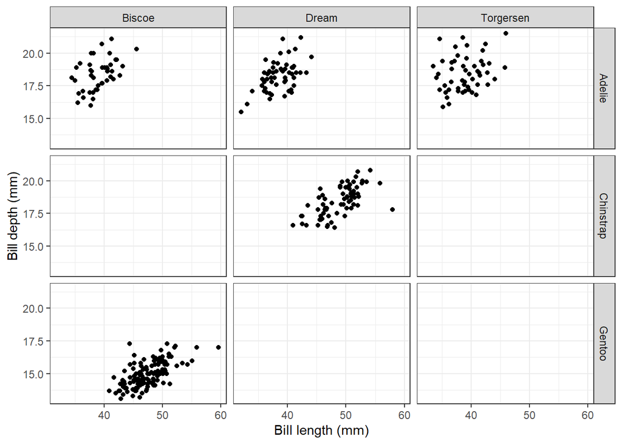

```r
# Edit this plot to be a six-panel figure
# With species as rows and islands as columns
p_length_depth <- ggplot(penguins, aes(x = bill_length_mm, y = bill_depth_mm)) +
  geom_point() +
  labs(x = "Bill length (mm)", y = "Bill depth (mm)") +
  theme_bw()

p_length_depth <- p_length_depth +
  facet_grid(species ~ island)
p_length_depth
```

```r
load(penguins)
```

```
## Error in load(penguins): bad 'file' argument
```

```r
penguins
```

```
## # A tibble: 344 × 8
##    species island    bill_length_mm bill_depth_mm flipper_length_mm body_mass_g
##    <fct>   <fct>              <dbl>         <dbl>             <int>       <int>
##  1 Adelie  Torgersen           39.1          18.7               181        3750
##  2 Adelie  Torgersen           39.5          17.4               186        3800
##  3 Adelie  Torgersen           40.3          18                 195        3250
##  4 Adelie  Torgersen           NA            NA                  NA          NA
##  5 Adelie  Torgersen           36.7          19.3               193        3450
##  6 Adelie  Torgersen           39.3          20.6               190        3650
##  7 Adelie  Torgersen           38.9          17.8               181        3625
##  8 Adelie  Torgersen           39.2          19.6               195        4675
##  9 Adelie  Torgersen           34.1          18.1               193        3475
## 10 Adelie  Torgersen           42            20.2               190        4250
## # ℹ 334 more rows
## # ℹ 2 more variables: sex <fct>, year <int>
```

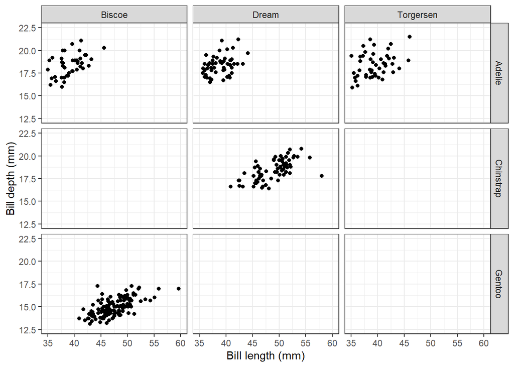

```r
# Edit your new plot to include more ticks on the x and y axes
p_length_depth <- p_length_depth +
  scale_x_continuous(breaks = seq(from = 35,to = 60, by = 5),
                     limits= c(35, 60))+
  scale_y_continuous(breaks = seq(from = 12.5, to = 22.5, by = 2.5),
                     limits = c(12.5, 22.5))

p_length_depth
```

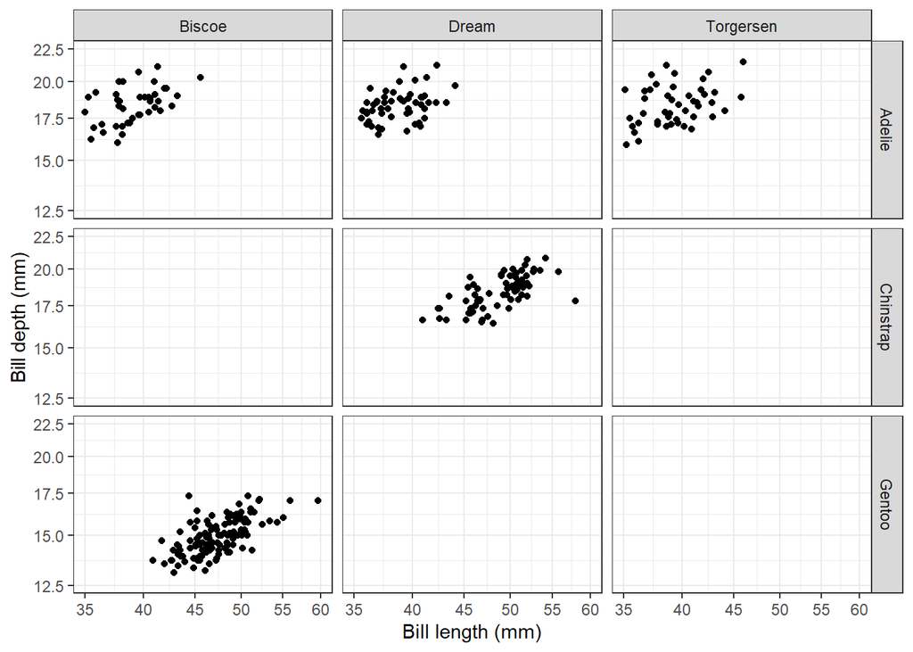

```r
# Edit your plot to transform to a log-log plot (both X and Y log-transformed)
p_length_depth <- p_length_depth +
  scale_x_continuous (breaks = seq(from = 35,to = 60, by = 5),
                     limits= c(35, 60),
                     trans = "log10") +
  scale_y_continuous(breaks = seq(from = 12.5, to = 22.5, by = 2.5),
                     limits = c(12.5, 22.5),
                     trans="log10")
p_length_depth
```

## Section 2: Width and position

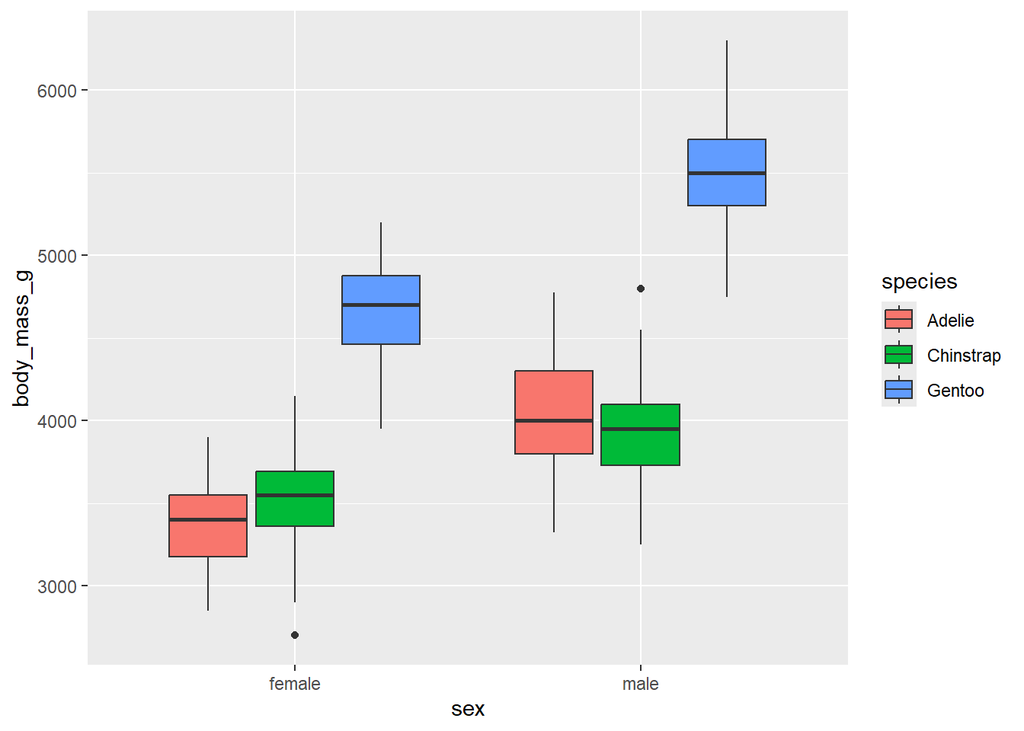

```r
# Here is a boxplot to start from:
box_sex_bm <- penguins %>%
  filter(!is.na(sex)) %>%
  ggplot(aes(x = sex, y = body_mass_g, fill = species)) +
  geom_boxplot()
box_sex_bm
```

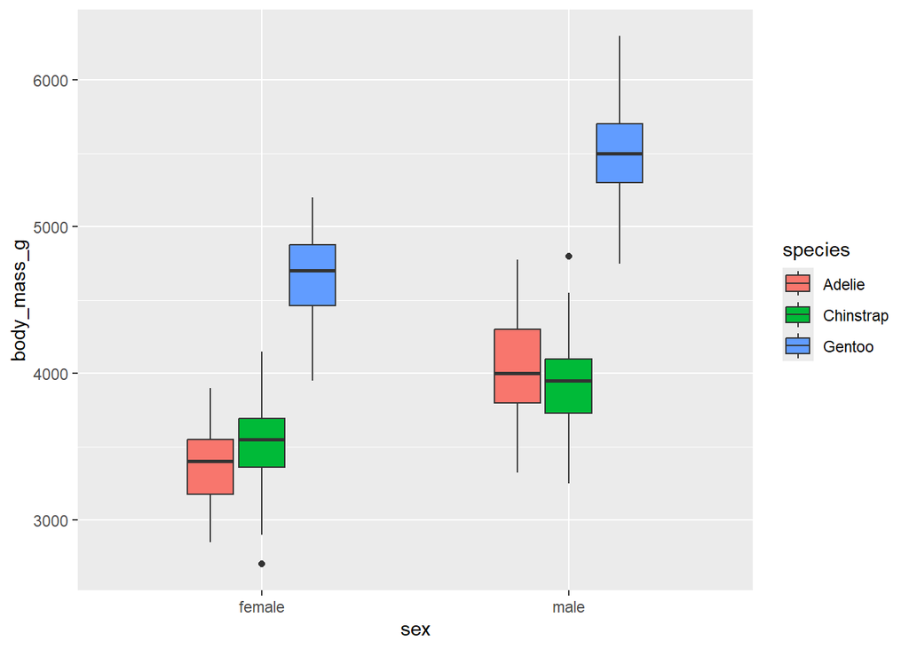

```r
# Change the boxplots to be narrower
penguins %>%
  filter(!is.na(sex)) %>%
  ggplot(aes(x = sex, y = body_mass_g, fill = species)) +
  geom_boxplot(width= .5)
```

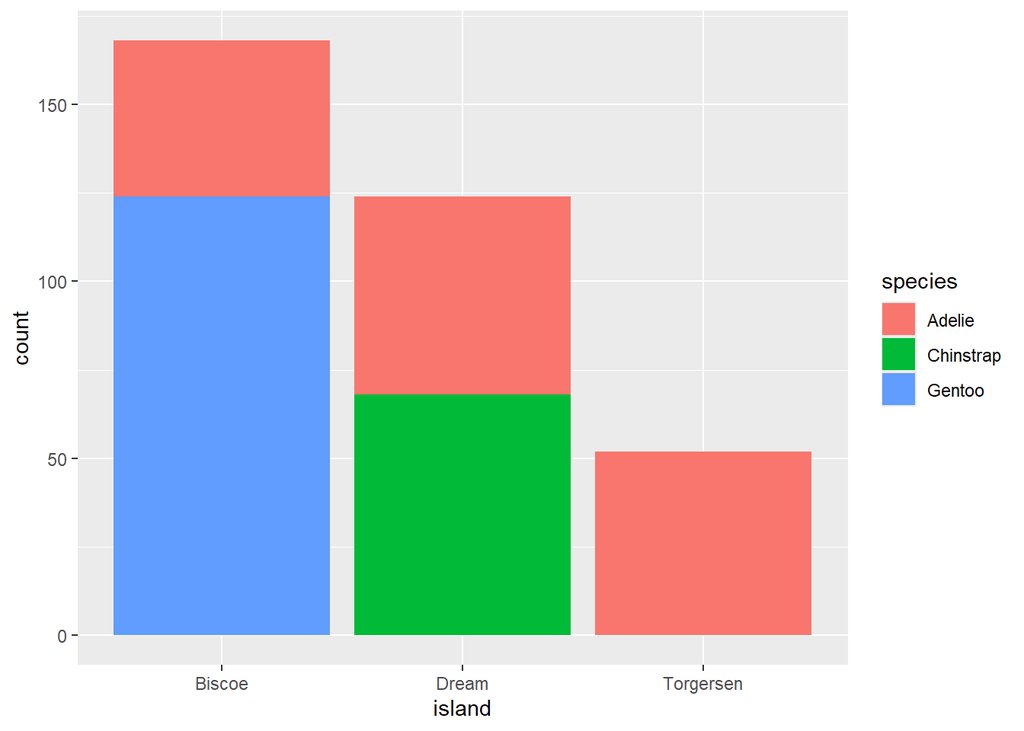

```r
# Create a stacked barplot of counts by island, colored by species
ggplot(penguins, aes(x = island, fill = species)) +
  geom_bar()
```

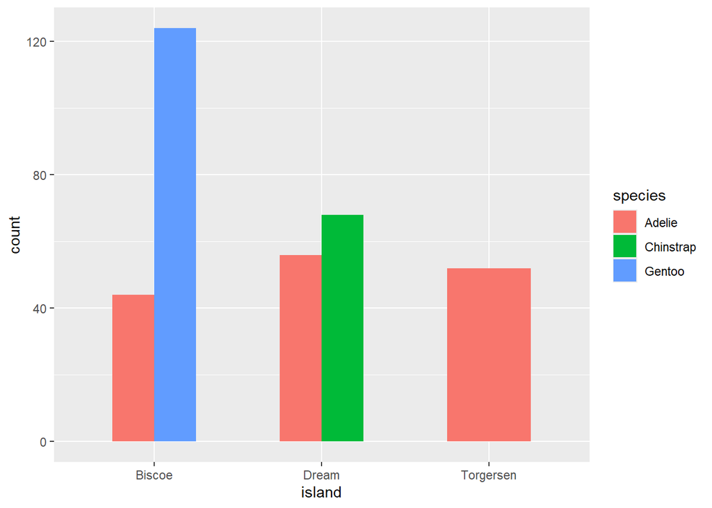

```r
# Move the bars to be side-by-side instead of stacked
barplot_isl <- ggplot(penguins, aes(x = island, fill = species)) +
  geom_bar(position = position_dodge(), width = .5)
barplot_isl
```

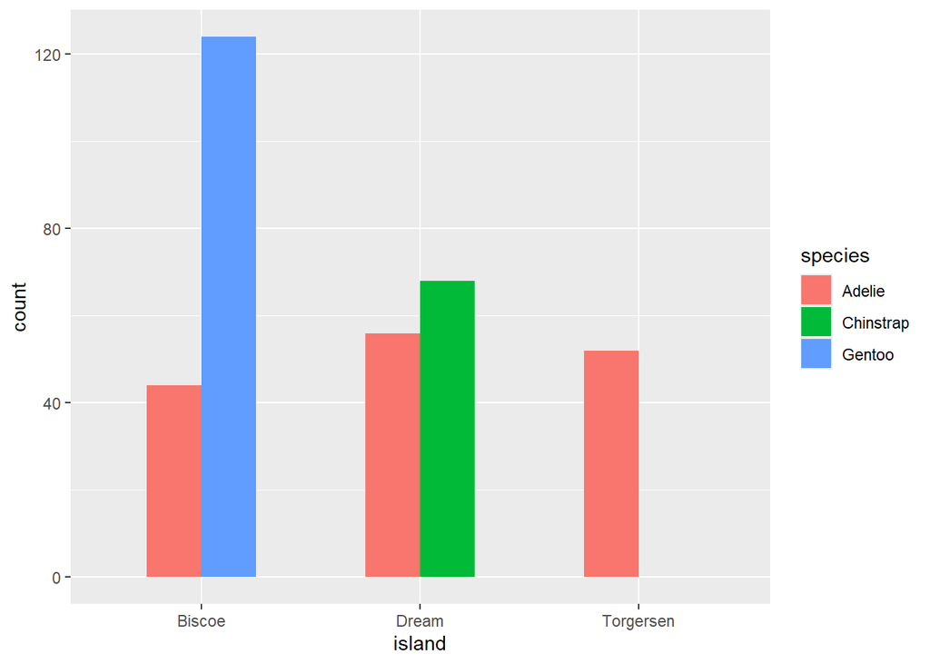

```r
# Make all the bars the same width
barplot_isl <- ggplot(penguins, aes(x = island, fill = species)) +
  geom_bar(position = position_dodge(width = .5, preserve = "single"),
           width = .5)
barplot_isl
```

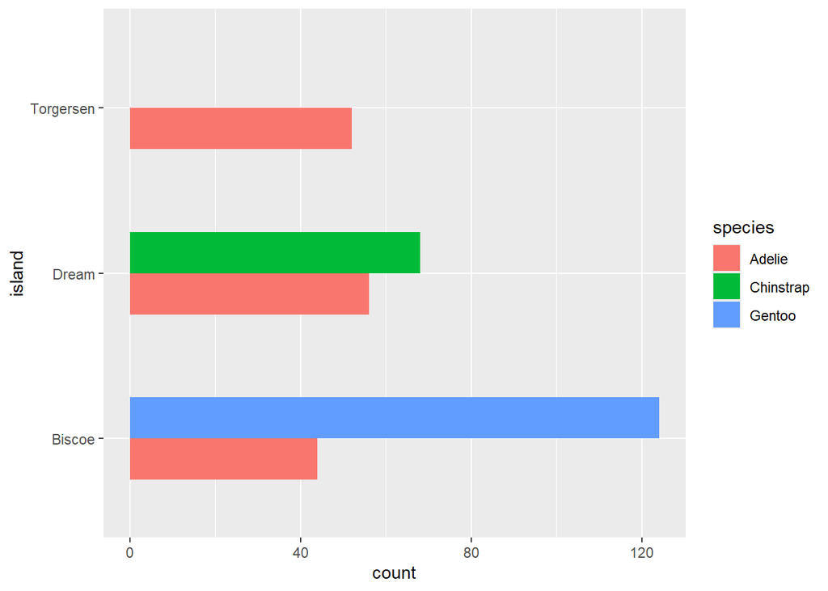

```r
# Flip the plot sideways (for an "Excel-style" bar chart)
barplot_90 <- barplot_isl +
  coord_flip()
barplot_90
```

## Section 3: Aesthetics (color, etc.) and legends

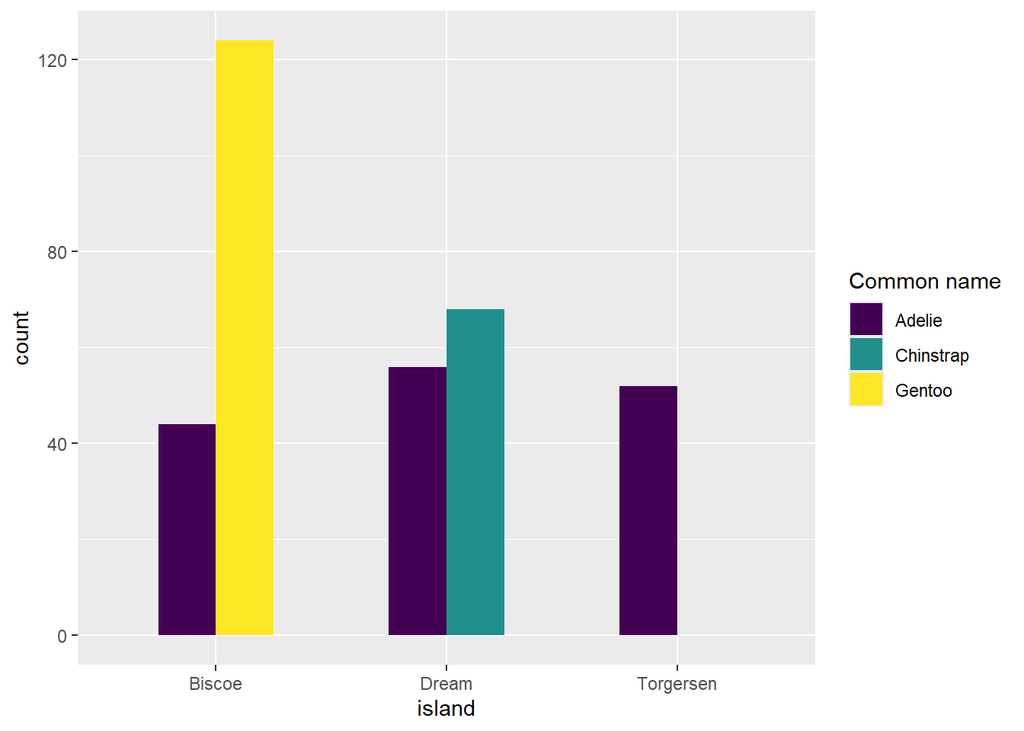

```r
# Use the viridis color scheme on your barplot from the last chunk
# (use whichever orientation you prefer)
# And change the title of the color legend to "Common name"
barplot_isl <- barplot_isl +
  scale_fill_viridis_d("Common name")
barplot_isl
```

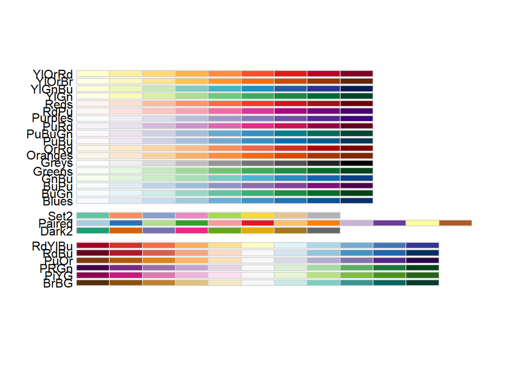

```r
# Use another color scheme on your barplot
# Make sure it is colorblind-friendly
RColorBrewer::display.brewer.all(colorblindFriendly = T)
```

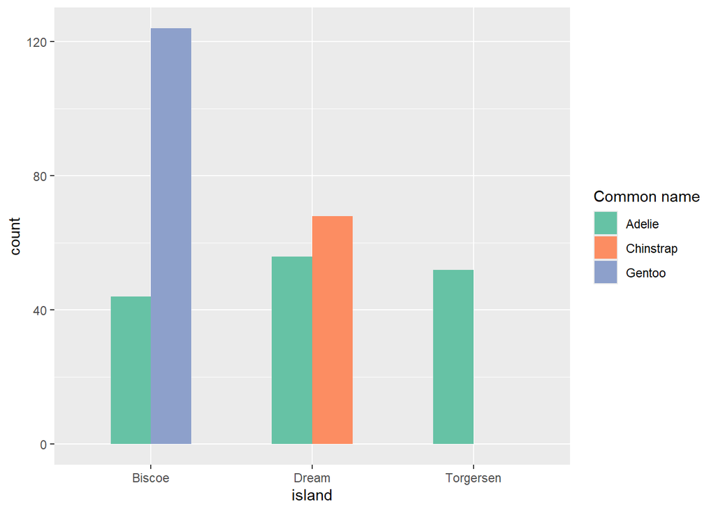

```r
barplot_isl +
 scale_fill_brewer("Common name",
                   palette = "Set2")
```

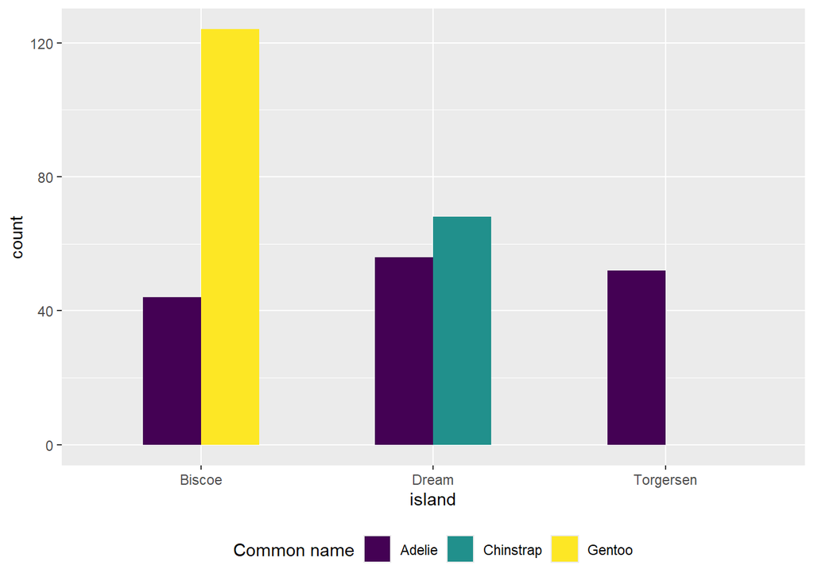

```r
# Move the legend to the bottom of the plot
barplot_isl +
  theme(legend.position = "bottom")
```

## Section 4: Themes

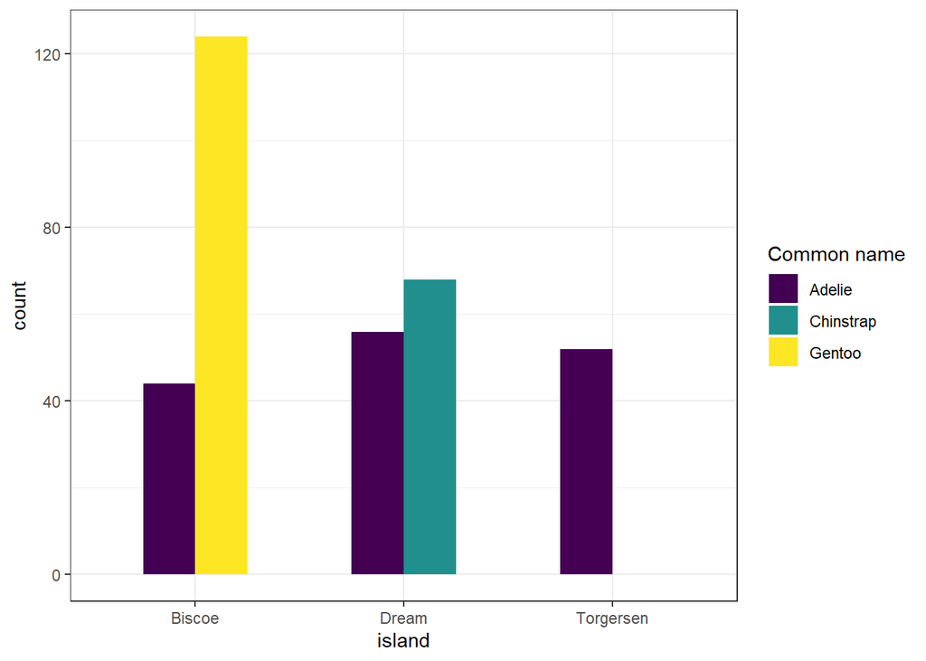

```r
# Apply the "black and white" theme
# It removes the gray background and adds axis lines
barplot_isl <- barplot_isl +
  theme_bw()
barplot_isl
```

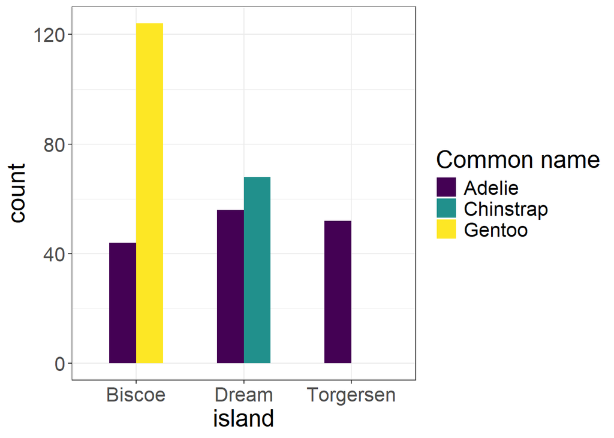

```r
# Increase the font size for all text
barplot_isl +
  theme(text = element_text(size=20))
```

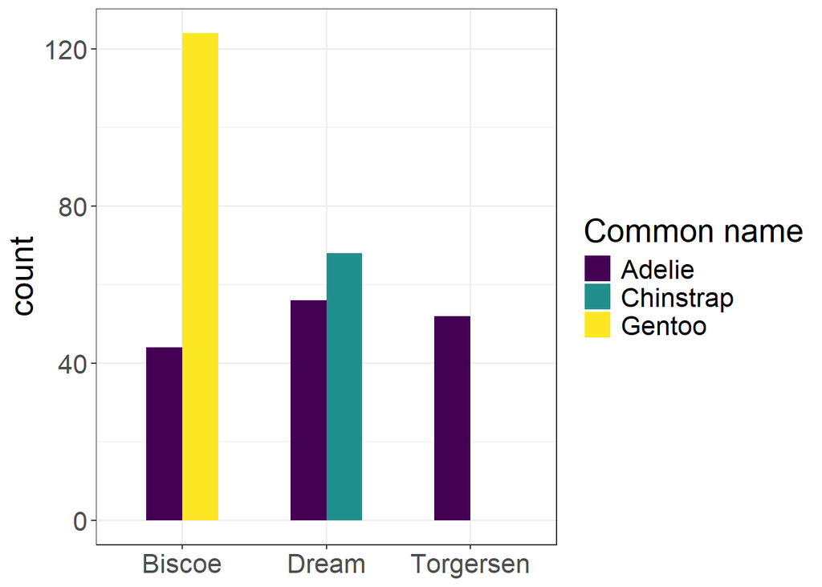

```r
# Remove the x-axis label ("island")
barplot_isl +
  theme(text = element_text(size=20), axis.title.x = element_blank())
```

## Section 5: Reverse-engineering plots

Reproduce each of these figures using `ggplot2`.

The first is a practice figure using `penguins`.

Some notes:

- The color names used in this figure are “darkorange”, “purple”, and “cyan4”.
- Pay attention to the y-axis range on the plot
- There is a built-in theme you can use - you do not need to manually modify axes, etc.

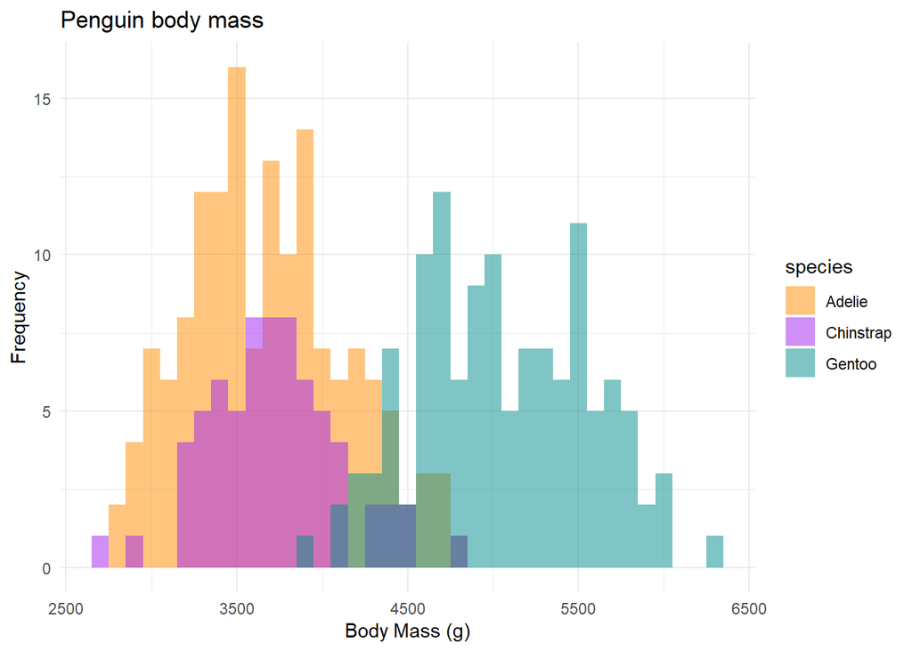

```r
ggplot(penguins, aes(x=body_mass_g, fill=species))+
  geom_histogram(binwidth = 100, position="identity", alpha = 0.5)+
  theme_minimal()+
  scale_fill_manual(values = c("darkorange", "purple", "cyan4"))+
labs(x = "Body Mass (g)", y = "Frequency") +
  ggtitle("Penguin body mass")+
  theme_minimal()
```

The second uses angling data from recreational fisheries, associated with the article Flink, H., Sundblad, G., Merilä, J., & Tibblin, P. (2024). Recreational fisheries selectively capture and harvest large predators. Fish and Fisheries, 25(5), 793-805.

The data can be found here: Flink, Henrik; Sundblad, Göran; Merilä, Juha; Tibblin, Petter (2024). Data and code from: Recreational fisheries selectively capture and harvest large predators [Dataset]. Dryad. https://doi.org/10.5061/dryad.m0cfxppbg

- This plot shows the mean and *two standard errors* of the mean by species, year, and fate of the fish (released or harvested)
- It only plots the top six species in terms of number of data points
- The colors are from the “R Color Brewer” package/palette

```r
library(RColorBrewer)
fish_data <- read_csv(here("scripts/data/Angling_data.csv"))
unique(fish_data$SpeciesName)
```

```
##  [1] "northern pike"   "pikeperch"       "perch"           "common bream"
##  [5] "roach"           "silver bream"    "tench"           "rudd"
##  [9] "whitefish"       "burbot"          "vendace"         "eel"
## [13] "common bleak"    "char"            "lake trout"      "asp"
## [17] "chub"            "ruffe"           "herring"         "atlantic salmon"
## [21] "rainbow trout"   "common carp"     "catfish"         "zope"
## [25] "grass carp"      "common dace"     "crucian carp"    "european smelt"
## [29] "ide"
```

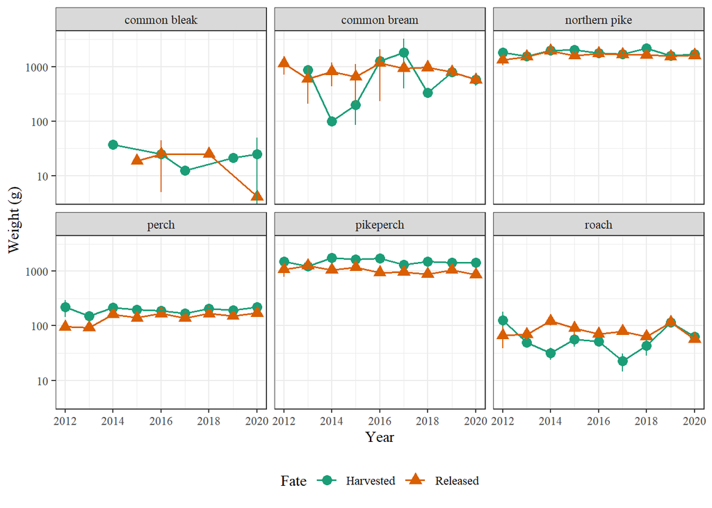

```r
fish_filtered <- fish_data %>%
  filter(SpeciesName %in% c("common bleak", "common bream", "northern pike", "perch", "pikeperch", "roach"),
         Fate != "No Answer")


summary_data <- fish_filtered %>%
  group_by(SpeciesName, Year, Fate) %>%
  summarise(
    mean_weight = mean(Weight, na.rm = TRUE),
    se = sd(Weight, na.rm = TRUE) / sqrt(n()),
    n = n(),
    .groups = 'drop'
  ) %>%
  mutate(
    lower = mean_weight - (2 * se),
    upper = mean_weight + (2 * se)
  )

summary_data <- summary_data %>%
  filter(!is.na(mean_weight))



ggplot(summary_data, aes(x = Year, y = mean_weight, color = Fate, shape = Fate)) +
  geom_point(size=3, na.rm = TRUE) +
  geom_line(size=.6, na.rm = TRUE)+
  geom_errorbar(aes(ymin = lower, ymax = upper,
                width = 0)) +
   scale_color_brewer(palette = "Dark2") +
  facet_wrap(~SpeciesName) +
  labs(
    y = "Weight (g)") +
  scale_y_log10()+
  theme_bw(base_family = "serif")+ theme(legend.position = "bottom")
```

## Exercise 9 Questions

1. What is the difference between a “scale” and a “theme” in ggplot?